# Assessing the gene expression of Crepidula fornicata under pH stress

Christopher Reyes, Kostas Kontodimas, Xuqing Chen

April 4, 2019

Version Control: R version 3.5.1 (2018-07-02) “DESeq” 1.34.1 “affycoretools” 1.54.0 “arrayQualityMetrics” 3.38.0 “genefilter” 1.64.0 “DESeq2” 1.22.2 “ggplot2” 3.1.0 “dplyr” 0.8.0.1 “RColorBrewer” 1.1.2 “gplots” 3.0.1.1 “pheatmap” 1.0.12 “vegan” 2.5.4 “ggrepel” 0.8.0 “tidyverse” 1.2.1

```r
#Array Quality Metrics
###Loading packages and setting up
source("http://bioconductor.org/biocLite.R")
```

```
## Bioconductor version 3.8 (BiocInstaller 1.32.1), ?biocLite for help
```

```r
#biocLite("DESeq2")
#BiocManager::install("package_name") #use to install whatever packages you might be missing

library(DESeq); #packageVersion("DESeq"); citation("DESeq")
```

```
## locfit 1.5-9.1    2013-03-22
```

```
##     Welcome to 'DESeq'. For improved performance, usability and
##     functionality, please consider migrating to 'DESeq2'.
```

```r
library(affycoretools); #packageVersion("affycoretools"); citation("affycoretools")
library(arrayQualityMetrics); #packageVersion("arrayQualityMetrics"); citation("arrayQualityMetrics")
library(genefilter); #packageVersion("genefilter"); citation("genefilter")

#conduct array quality metrics to get rid of outliers
#read in counts
countData <- read.table("brood37_2017.txt")
head(countData)
```

```
##       b37_0_8_1.fastq.trim.sam.counts b37_0_8_2.fastq.trim.sam.counts
## 00002                               2                               3
## 00004                              48                              39
## 00006                              17                              12
## 00007                               0                               4
## 00008                               2                               0
## 00009                              27                              27
##       b37_0_8_3.fastq.trim.sam.counts b37_0_8_4.fastq.trim.sam.counts
## 00002                               3                               0
## 00004                              39                              17
## 00006                              19                              10
## 00007                               1                               1
## 00008                               2                               1
## 00009                              23                              10
##       b37_10_7.5_1.fastq.trim.sam.counts
```

[output cut: 139 more lines]

```r
length(countData[,1])
```

```
## [1] 20788
```

```r
#20788
row.names(countData)=sub("", "isogroup", rownames(countData))
head(countData)
```

```
##               b37_0_8_1.fastq.trim.sam.counts
## isogroup00002                               2
## isogroup00004                              48
## isogroup00006                              17
## isogroup00007                               0
## isogroup00008                               2
## isogroup00009                              27
##               b37_0_8_2.fastq.trim.sam.counts
## isogroup00002                               3
## isogroup00004                              39
## isogroup00006                              12
## isogroup00007                               4
## isogroup00008                               0
## isogroup00009                              27
##               b37_0_8_3.fastq.trim.sam.counts
## isogroup00002                               3
## isogroup00004                              39
## isogroup00006                              19
## isogroup00007                               1
## isogroup00008                               2
## isogroup00009                              23
##               b37_0_8_4.fastq.trim.sam.counts
## isogroup00002                               0
## isogroup00004                              17
## isogroup00006                              10
## isogroup00007                               1
## isogroup00008                               1
## isogroup00009                              10
##               b37_10_7.5_1.fastq.trim.sam.counts
## isogroup00002                                  1
## isogroup00004                                 24
## isogroup00006                                 21
## isogroup00007                                  2
## isogroup00008                                  2
## isogroup00009                                 24
##               b37_10_7.5_2.fastq.trim.sam.counts
## isogroup00002                                  0
## isogroup00004                                 43
## isogroup00006                                 32
## isogroup00007                                  0
```

[output cut: 197 more lines]

```
## isogroup00009                               1
##               b37_4_8_3.fastq.trim.sam.counts
## isogroup00002                               0
## isogroup00004                              10
## isogroup00006                               3
## isogroup00007                               0
## isogroup00008                               0
## isogroup00009                               2
##               b37_4_8_4.fastq.trim.sam.counts
## isogroup00002                               0
## isogroup00004                               1
## isogroup00006                               0
## isogroup00007                               0
## isogroup00008                               0
## isogroup00009                               3
```

```r
treat=c( "pH8", "pH8",  "pH8", "pH8","pH7.5", "pH7.5", "pH7.5", "pH7.5","pH8", "pH8", "pH8", "pH8","pH7.5", "pH7.5", "pH7.5", "pH7.5","pH8", "pH8", "pH8", "pH8","pH7.5", "pH7.5", "pH7.5", "pH7.5","pH8", "pH8", "pH8", "pH8","pH7.5", "pH7.5", "pH7.5", "pH7.5","pH8", "pH8",  "pH8", "pH8")
hour=as.factor(c( "0", "0", "0", "0", "10",  "10", "10",  "10", "10", "10", "10", "10", "24", "24", "24", "24", "24", "24",  "24", "24",
                  "48", "48", "48","48", "48", "48", "48", "48", "4","4", "4", "4", "4", "4", "4", "4"))
conditions=data.frame(treat, hour)
nrow(conditions)
```

```
## [1] 36
```

```r
ncol(countData)
```

```
## [1] 36
```

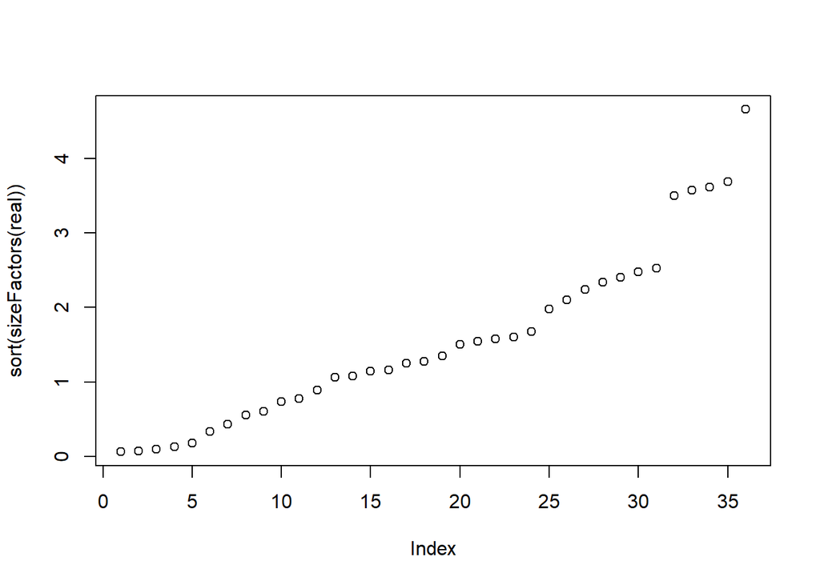

```r
real=newCountDataSet(countData,conditions)
real=estimateSizeFactors(real)
plot(sort(sizeFactors(real)))
```

```r
cds=estimateDispersions(real,method="blind")
vsdBlind=varianceStabilizingTransformation(cds)

arrayQualityMetrics(vsdBlind,intgroup=c("treat"), force=TRUE)
```

```
## The report will be written into directory 'arrayQualityMetrics report for vsdBlind'.
```

[output not shown]

[output cut: 49 more lines]

[output not shown]

Based on the arrayQualityMetrics, we determined that there are 5 outliers in our dataset. These samples are b37_10_7.5_4, b37_24_7.5_2, b37_24_7.5_4, b37_4_8_2, and b37_4_8_4.

```r
#Unloads DESeq before loading DESeq2 since the packages conflict
detach("package:DESeq", unload=TRUE)
#Load additional packages and filter data
library(DESeq2) #packageVersion("DESeq2"); citation("DESeq2")
```

```r
library(ggplot2) #packageVersion("ggplot2"); citation("ggplot2")
library(dplyr) #packageVersion("dplyr"); citation("dplyr")
library(RColorBrewer) #packageVersion("RColorBrewer"); citation("RColorBrewer")
library(gplots) #packageVersion("gplots"); citation("gplots")
library(pheatmap) #packageVersion("pheatmap"); citation("pheatmap")
library(vegan) #packageVersion("vegan"); citation("vegan")
library(ggrepel) #packageVersion("ggrepel"); citation("ggrepel")
library(tidyverse) #packageVersion("tidyverse"); citation("tidyverse")
#read in counts (old data pre-filtered)
countData <- read.table("brood37_2017.txt")
head(countData)
```

```
##       b37_0_8_1.fastq.trim.sam.counts b37_0_8_2.fastq.trim.sam.counts
## 00002                               2                               3
## 00004                              48                              39
## 00006                              17                              12
## 00007                               0                               4
## 00008                               2                               0
## 00009                              27                              27
##       b37_0_8_3.fastq.trim.sam.counts b37_0_8_4.fastq.trim.sam.counts
## 00002                               3                               0
## 00004                              39                              17
## 00006                              19                              10
## 00007                               1                               1
## 00008                               2                               1
## 00009                              23                              10
##       b37_10_7.5_1.fastq.trim.sam.counts
```

[output cut: 139 more lines]

```r
length(countData[,1])
```

```
## [1] 20788
```

```r
#20788

names(countData)=sub(".fastq.trim.sam.counts","",names(countData))
names(countData)
```

```
##  [1] "b37_0_8_1"    "b37_0_8_2"    "b37_0_8_3"    "b37_0_8_4"
##  [5] "b37_10_7.5_1" "b37_10_7.5_2" "b37_10_7.5_3" "b37_10_7.5_4"
##  [9] "b37_10_8_1"   "b37_10_8_2"   "b37_10_8_3"   "b37_10_8_4"
## [13] "b37_24_7.5_1" "b37_24_7.5_2" "b37_24_7.5_3" "b37_24_7.5_4"
## [17] "b37_24_8_1"   "b37_24_8_2"   "b37_24_8_3"   "b37_24_8_4"
## [21] "b37_48_7.5_1" "b37_48_7.5_2" "b37_48_7.5_3" "b37_48_7.5_4"
## [25] "b37_48_8_1"   "b37_48_8_2"   "b37_48_8_3"   "b37_48_8_4"
## [29] "b37_4_7.5_1"  "b37_4_7.5_2"  "b37_4_7.5_3"  "b37_4_7.5_4"
## [33] "b37_4_8_1"    "b37_4_8_2"    "b37_4_8_3"    "b37_4_8_4"
```

```r
row.names(countData)=sub("", "isogroup", rownames(countData))
names(countData)
```

```
##  [1] "b37_0_8_1"    "b37_0_8_2"    "b37_0_8_3"    "b37_0_8_4"
##  [5] "b37_10_7.5_1" "b37_10_7.5_2" "b37_10_7.5_3" "b37_10_7.5_4"
##  [9] "b37_10_8_1"   "b37_10_8_2"   "b37_10_8_3"   "b37_10_8_4"
## [13] "b37_24_7.5_1" "b37_24_7.5_2" "b37_24_7.5_3" "b37_24_7.5_4"
## [17] "b37_24_8_1"   "b37_24_8_2"   "b37_24_8_3"   "b37_24_8_4"
## [21] "b37_48_7.5_1" "b37_48_7.5_2" "b37_48_7.5_3" "b37_48_7.5_4"
## [25] "b37_48_8_1"   "b37_48_8_2"   "b37_48_8_3"   "b37_48_8_4"
## [29] "b37_4_7.5_1"  "b37_4_7.5_2"  "b37_4_7.5_3"  "b37_4_7.5_4"
## [33] "b37_4_8_1"    "b37_4_8_2"    "b37_4_8_3"    "b37_4_8_4"
```

```r
#removing outlier samples (generally ones that failed to sequence)
countData$b37_10_7.5_4 <- NULL
countData$b37_24_7.5_2 <- NULL
countData$b37_24_7.5_4 <- NULL
countData$b37_4_8_2 <- NULL
countData$b37_4_8_4 <- NULL

totalCounts=colSums(countData)
totalCounts
```

```
##    b37_0_8_1    b37_0_8_2    b37_0_8_3    b37_0_8_4 b37_10_7.5_1
##       336730       356055       333506        94580       293991
## b37_10_7.5_2 b37_10_7.5_3   b37_10_8_1   b37_10_8_2   b37_10_8_3
##       428073       518635       183215       172071       201308
##   b37_10_8_4 b37_24_7.5_1 b37_24_7.5_3   b37_24_8_1   b37_24_8_2
##       477596       242820       290971       134158       459242
##   b37_24_8_3   b37_24_8_4 b37_48_7.5_1 b37_48_7.5_2 b37_48_7.5_3
##       107132       733579       478810      1013390       132901
## b37_48_7.5_4   b37_48_8_1   b37_48_8_2   b37_48_8_3   b37_48_8_4
##       235836       352352       744843       221007       502253
##  b37_4_7.5_1  b37_4_7.5_2  b37_4_7.5_3  b37_4_7.5_4    b37_4_8_1
##       485919       760918       246193       266035       778342
##    b37_4_8_3
##        78335
```

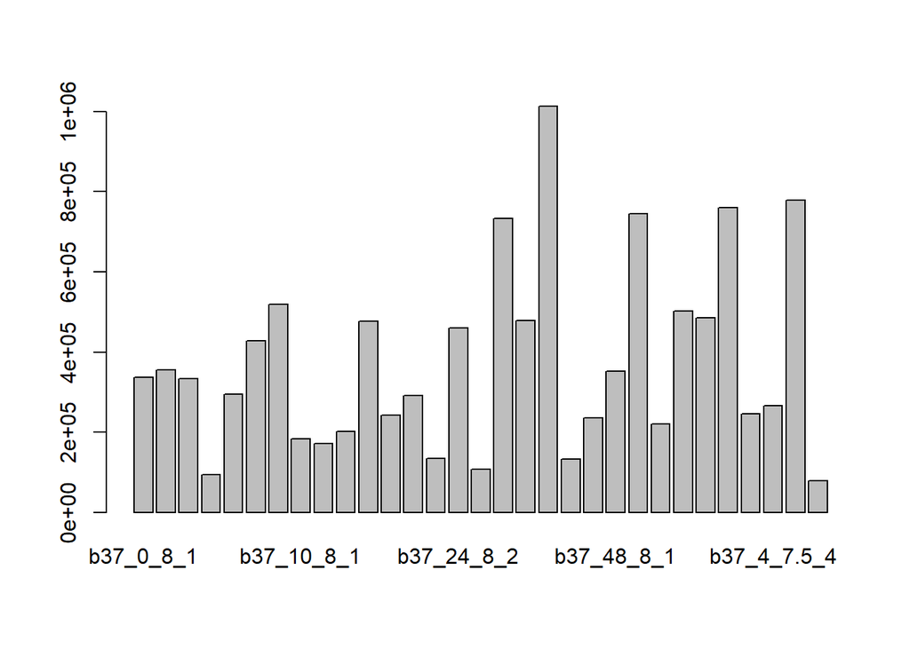

```r
barplot(totalCounts)
```

```r
#  b37_0_8_1    b37_0_8_2    b37_0_8_3    b37_0_8_4 b37_10_7.5_1 b37_10_7.5_2
#336730       356055       333506        94580       293991       428073
#b37_10_7.5_3   b37_10_8_1   b37_10_8_2   b37_10_8_3   b37_10_8_4 b37_24_7.5_1
#518635       183215       172071       201308       477596       242820
#b37_24_7.5_3   b37_24_8_1   b37_24_8_2   b37_24_8_3   b37_24_8_4 b37_48_7.5_1
#290971       134158       459242       107132       733579       478810
#b37_48_7.5_2 b37_48_7.5_3 b37_48_7.5_4   b37_48_8_1   b37_48_8_2   b37_48_8_3
#1013390       132901       235836       352352       744843       221007
#b37_48_8_4  b37_4_7.5_1  b37_4_7.5_2  b37_4_7.5_3  b37_4_7.5_4    b37_4_8_1
#502253       485919       760918       246193       266035       778342
#b37_4_8_3
#78335

min(totalCounts) #78,335
```

```
## [1] 78335
```

```r
max(totalCounts)  # 1,013,390
```

```
## [1] 1013390
```

```r
#Remove day 0 data since it can't be compared between treatments (only pH 8 treatment available)
countData$b37_0_8_1 <- NULL
countData$b37_0_8_2 <- NULL
countData$b37_0_8_3 <- NULL
countData$b37_0_8_4 <- NULL

treat=c( "pH7.5", "pH7.5", "pH7.5","pH8", "pH8", "pH8", "pH8", "pH7.5", "pH7.5","pH8", "pH8", "pH8", "pH8","pH7.5", "pH7.5", "pH7.5", "pH7.5","pH8", "pH8", "pH8", "pH8","pH7.5", "pH7.5", "pH7.5", "pH7.5","pH8", "pH8")
hour=as.factor(c( "10", "10", "10", "10", "10", "10", "10", "24", "24", "24", "24", "24", "24","48", "48", "48","48", "48", "48", "48", "48", "4","4", "4", "4", "4", "4"))
```

We were only interested in looking at the data for 48 hours and so we had to subset that data from our overall data and use it for subsequent analyses.

```r
#Assess 48 hour data
g=data.frame(treat, hour)
g
```

```
##    treat hour
## 1  pH7.5   10
## 2  pH7.5   10
## 3  pH7.5   10
## 4    pH8   10
## 5    pH8   10
## 6    pH8   10
## 7    pH8   10
## 8  pH7.5   24
## 9  pH7.5   24
## 10   pH8   24
## 11   pH8   24
## 12   pH8   24
## 13   pH8   24
## 14 pH7.5   48
## 15 pH7.5   48
## 16 pH7.5   48
## 17 pH7.5   48
## 18   pH8   48
## 19   pH8   48
## 20   pH8   48
## 21   pH8   48
## 22 pH7.5    4
## 23 pH7.5    4
## 24 pH7.5    4
## 25 pH7.5    4
## 26   pH8    4
## 27   pH8    4
```

```r
colData<- g
colData48 = colData[colData$hour == 48,]

dds<-DESeqDataSetFromMatrix(countData=countData, colData=colData, design=~treat+hour+treat*hour )
head(dds)
```

```
## class: DESeqDataSet
## dim: 6 27
## metadata(1): version
## assays(1): counts
## rownames(6): isogroup00002 isogroup00004 ... isogroup00008
##   isogroup00009
## rowData names(0):
## colnames(27): b37_10_7.5_1 b37_10_7.5_2 ... b37_4_8_1 b37_4_8_3
## colData names(2): treat hour
```

```r
dds48 = dds[,colData$hour == 48]
head(dds48)
```

```
## class: DESeqDataSet
## dim: 6 8
## metadata(1): version
## assays(1): counts
## rownames(6): isogroup00002 isogroup00004 ... isogroup00008
##   isogroup00009
## rowData names(0):
## colnames(8): b37_48_7.5_1 b37_48_7.5_2 ... b37_48_8_3 b37_48_8_4
## colData names(2): treat hour
```

```r
design(dds48) = ~treat
dds48<-DESeq(dds48)
# estimating size factors
# estimating dispersions
# gene-wise dispersion estimates
# mean-dispersion relationship
# final dispersion estimates
# fitting model and testing
head(dds48)
```

```
## class: DESeqDataSet
## dim: 6 8
## metadata(1): version
## assays(4): counts mu H cooks
## rownames(6): isogroup00002 isogroup00004 ... isogroup00008
##   isogroup00009
## rowData names(22): baseMean baseVar ... deviance maxCooks
## colnames(8): b37_48_7.5_1 b37_48_7.5_2 ... b37_48_8_3 b37_48_8_4
## colData names(3): treat hour sizeFactor
```

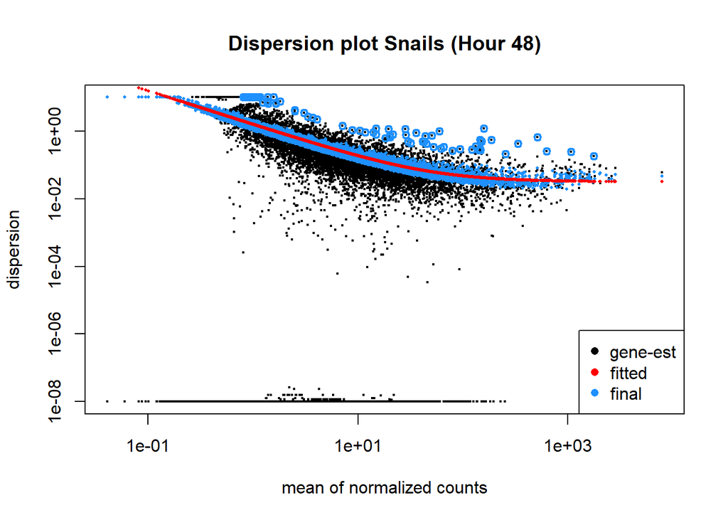

```r
res48<- results(dds48)

#Look at dispersions plot
plotDispEsts(dds48, main="Dispersion plot Snails (Hour 48)")
```

The dispersion plot has the “hockey stick” look that we would expect. It uses a shrinking method to reduce false positives in the differential expression analysis. Black dots represent genes, the red line is a model fit to the genes, and the blue dots are the genes after they’ve been processed through the shrinking method. Genes with low dispersion estimates are shrunken towards the curve and are the output for differential expression testing. Dispersion estimates slightly above the curve are also shrunken, but those with extreme high dispersion are not. These genes, shown as surrounded by blue circles, likely do not follow the model assumptions and have higher variability. Shrinking them would only lead to false positives.

```r
###Assess Pco2 treatments: pH8 vs pH7.5
respH75.48 <- results(dds48, contrast=c("treat","pH7.5","pH8"))
table(respH75.48$padj<.1)
```

```
##
## FALSE  TRUE
##  2166    25
```

```r
table(respH75.48$padj<.05)
```

```
##
## FALSE  TRUE
##  2177    14
```

```r
table(respH75.48$padj<.01)
```

```
##
## FALSE  TRUE
##  2182     9
```

```r
# 0.1=25/2191
# 0.05=14/2191
# 0.01=9/2191
summary(respH75.48)
```

```
##
## out of 19850 with nonzero total read count
## adjusted p-value < 0.1
## LFC > 0 (up)       : 11, 0.055%
## LFC < 0 (down)     : 14, 0.071%
## outliers [1]       : 0, 0%
## low counts [2]     : 17659, 89%
## (mean count < 25)
## [1] see 'cooksCutoff' argument of ?results
## [2] see 'independentFiltering' argument of ?results
```

```r
#LFC>0: 11, 0.055%
#LFC<0: 14, 0.071%
#Outliers: 0, 0%
#Low counts: 17659, 89%

nrow(respH75.48[respH75.48$padj<0.05 & !is.na(respH75.48$padj),])
```

```
## [1] 14
```

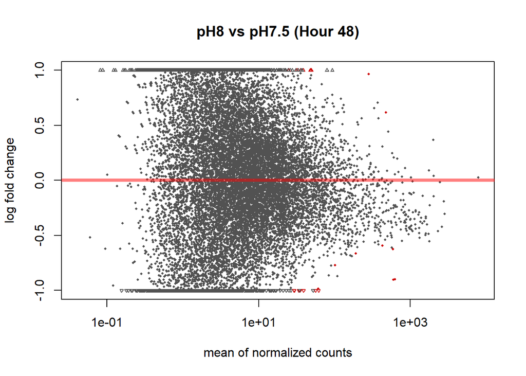

```r
# Num significantly differentially expressed genes excluding the no/low count genes   #14

#scatterplot of logarithmic fold changes versus the mean of normalized counts
plotMA(respH75.48, main="pH8 vs pH7.5 (Hour 48)", ylim=c(-1,1))
```

```r
results75.48 <- as.data.frame(respH75.48)
head(results75.48)
```

```
##                baseMean log2FoldChange     lfcSE       stat    pvalue
## isogroup00002  3.401892    -0.37125067 0.8768335 -0.4233993 0.6720040
## isogroup00004 39.983615     0.08546704 0.3431567  0.2490613 0.8033134
## isogroup00006 27.409281    -0.11323858 0.3225585 -0.3510637 0.7255406
## isogroup00007  1.445529     0.52327739 1.4414184  0.3630295 0.7165829
## isogroup00008  1.311991     0.29631196 1.2709908  0.2331346 0.8156569
## isogroup00009 26.309618     0.20034867 0.3405923  0.5882360 0.5563739
##                    padj
## isogroup00002        NA
## isogroup00004 0.9554177
## isogroup00006 0.9273710
## isogroup00007        NA
## isogroup00008        NA
## isogroup00009 0.8763567
```

```r
nrow(respH75.48[respH75.48$padj<0.1 & respH75.48$log2FoldChange > 0 & !is.na(respH75.48$padj),])
```

```
## [1] 11
```

```r
nrow(respH75.48[respH75.48$padj<0.1 & respH75.48$log2FoldChange < -0 & !is.na(respH75.48$padj),])
```

```
## [1] 14
```

```r
#UP in 7.5 (Hour 48): 11
#DOWN in 7.5 (Hour 48): 14

write.table(respH75.48, file="b37_7.5.48_2017.txt", quote=F, sep="\t")

cp48 <- read.table("b37_7.5.48_2017.txt")
head(cp48)
```

```
##                baseMean log2FoldChange     lfcSE       stat    pvalue
## isogroup00002  3.401892    -0.37125067 0.8768335 -0.4233993 0.6720040
## isogroup00004 39.983615     0.08546704 0.3431567  0.2490613 0.8033134
## isogroup00006 27.409281    -0.11323858 0.3225585 -0.3510637 0.7255406
## isogroup00007  1.445529     0.52327739 1.4414184  0.3630295 0.7165829
## isogroup00008  1.311991     0.29631196 1.2709908  0.2331346 0.8156569
## isogroup00009 26.309618     0.20034867 0.3405923  0.5882360 0.5563739
##                    padj
## isogroup00002        NA
## isogroup00004 0.9554177
## isogroup00006 0.9273710
## isogroup00007        NA
## isogroup00008        NA
## isogroup00009 0.8763567
```

```
##                baseMean log2FoldChange     lfcSE       stat    pvalue
## isogroup00002 1.7663375    -0.37125067 0.8768335 -0.4233993 0.6720040
## isogroup00004 5.3213370     0.08546704 0.3431567  0.2490613 0.8033134
## isogroup00006 4.7765926    -0.11323858 0.3225585 -0.3510637 0.7255406
## isogroup00007 0.5315977     0.52327739 1.4414184  0.3630295 0.7165829
## isogroup00008 0.3917579     0.29631196 1.2709908  0.2331346 0.8156569
## isogroup00009 4.7175184     0.20034867 0.3405923  0.5882360 0.5563739
##                    padj dotcol
## isogroup00002        NA   <NA>
## isogroup00004 0.9554177  black
## isogroup00006 0.9273710  black
## isogroup00007        NA   <NA>
## isogroup00008        NA   <NA>
## isogroup00009 0.8763567  black
```

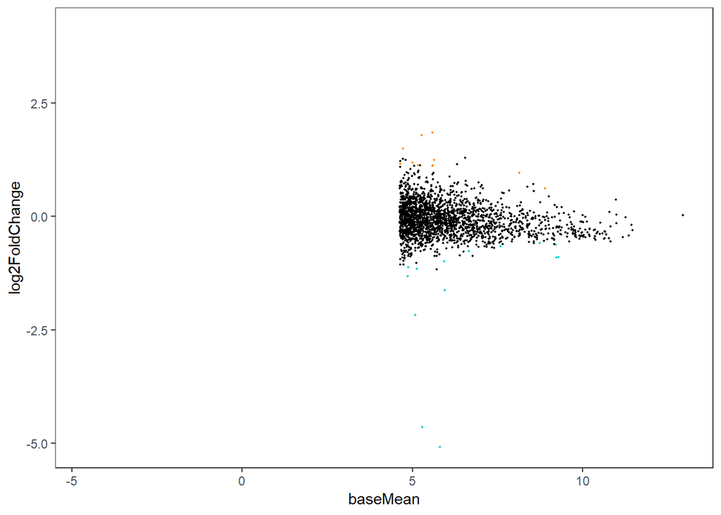

```r
MAttPlot <- function(df) {
  df$dotcol <- ifelse(df$log2FoldChange > 0 & df$padj < 0.1, 'darkorange',
                      ifelse(df$log2FoldChange < 0 & df$padj < 0.1, 'cyan3', 'black'))
  df$baseMean <- log2(df$baseMean)
  print(head(df))
  gg <- ggplot(df, aes(baseMean, log2FoldChange)) +
    geom_point(size = .3, color = df$dotcol) +
    theme_bw() +
    theme(panel.grid = element_blank())
  print(gg)
}

MAttPlot(cp48)
```

```r
#orange dots = upregulated, blue dots = downregulated
```

The MA-plot shows log2 fold changes attributable to treatment. Points are red if the adjusted p-value is less than 0.1. Arrows at the top and bottom of the figure indicate points outside the margins of the plot.

The Mattplot is similar except it uses a base mean rather than mean of normalized counts. Orange dots are significantly upregulated and blue dots are significantly downregulated.

```r
##make the GO table for MWU
cp48$isogroup=row.names(cp48)
library(dplyr)
go_input_7.5.48 = cp48 %>%
  mutate(mutated_p = -log(pvalue)) %>%
  mutate(mutated_p_updown = ifelse(log2FoldChange < 0, mutated_p*-1, mutated_p*1)) %>%
  na.omit() %>%
  select(isogroup, mutated_p_updown)
head(go_input_7.5.48)
```

```
##         isogroup mutated_p_updown
## 2  isogroup00004       0.21901036
## 3  isogroup00006      -0.32083826
## 6  isogroup00009       0.58631479
## 8  isogroup00011       1.43096725
## 12 isogroup00016      -0.01056541
## 13 isogroup00017       6.90359768
```

```r
colnames(go_input_7.5.48) <- c("gene", "pval")
head(go_input_7.5.48)
```

```
##             gene        pval
## 2  isogroup00004  0.21901036
## 3  isogroup00006 -0.32083826
## 6  isogroup00009  0.58631479
## 8  isogroup00011  1.43096725
## 12 isogroup00016 -0.01056541
## 13 isogroup00017  6.90359768
```

```r
write.csv(go_input_7.5.48, file="b37_7.5.48_rec_GO.csv", quote=F, row.names=FALSE)
```

```r
#GO enrichment analysis
#######MF
# Edit these to match your data file names:
input="b37_7.5.48_rec_GO.csv" # two columns of comma-separated values: gene id, continuous measure of significance. To perform standard GO enrichment analysis based on Fisher's exact test, use binary measure (0 or 1, i.e., either sgnificant or not).
goAnnotations="Crep454_iso2go.tab" # two-column, tab-delimited, one line per gene, multiple GO terms separated by semicolon. If you have multiple lines per gene, use nrify_GOtable.pl prior to running this script.
goDatabase="go.obo" # download from http://www.geneontology.org/GO.downloads.ontology.shtml
goDivision="MF" # either MF, or BP, or CC
source("gomwu.functions.R")


# Calculating stats. It might take ~3 min for MF and BP. Do not rerun it if you just want to replot the data with different cutoffs, go straight to gomwuPlot. If you change any of the numeric values below, delete the files that were generated in previos runs first.
gomwuStats(input, goDatabase, goAnnotations, goDivision,
    perlPath="perl", # replace with full path to perl executable if it is not in your system's PATH already
    largest=0.1,  # a GO category will not be considered if it contains more than this fraction of the total number of genes
    smallest=5,   # a GO category should contain at least this many genes to be considered
    clusterCutHeight=0.25, # threshold for merging similar (gene-sharing) terms. See README for details.
#   Alternative="g" # by default the MWU test is two-tailed; specify "g" or "l" of you want to test for "greater" or "less" instead.
#   Module=TRUE,Alternative="g" # un-remark this if you are analyzing a SIGNED WGCNA module (values: 0 for not in module genes, kME for in-module genes). In the call to gomwuPlot below, specify absValue=0.001 (count number of "good genes" that fall into the module)
#   Module=TRUE # un-remark this if you are analyzing an UNSIGNED WGCNA module
)
```

```
## Continuous measure of interest: will perform MWU test
## 3  GO terms at 10% FDR
```

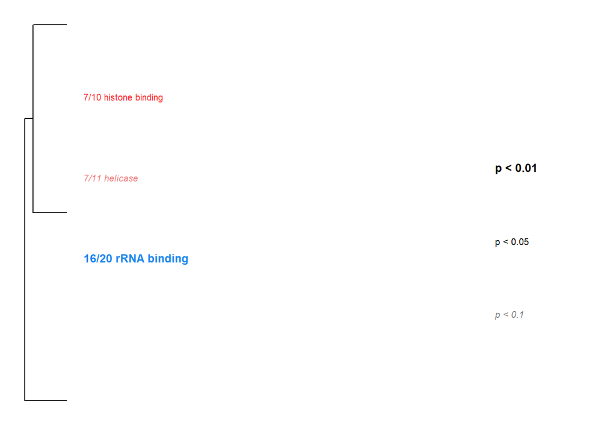

```
## GO terms dispayed:  3
## "Good genes" accounted for:  28 out of 205 ( 14% )
```

```r
# do not continue if the printout shows that no GO terms pass 10% FDR.


# Plotting results
results=gomwuPlot(input,goAnnotations,goDivision,
#   absValue=-log(0.05,10),  # genes with the measure value exceeding this will be counted as "good genes". Specify absValue=0.001 if you are doing Fisher's exact test for standard GO enrichment or analyzing a WGCNA module (all non-zero genes = "good genes").
    absValue=1,
    level1=0.1, # FDR threshold for plotting. Specify level1=1 to plot all GO categories containing genes exceeding the absValue.
    level2=0.05, # FDR cutoff to print in regular (not italic) font.
    level3=0.01, # FDR cutoff to print in large bold font.
    txtsize=1.2,    # decrease to fit more on one page, or increase (after rescaling the plot so the tree fits the text) for better "word cloud" effect
    treeHeight=0.5, # height of the hierarchical clustering tree
#   colors=c("dodgerblue2","firebrick1","skyblue2","lightcoral") # these are default colors, un-remar and change if needed
)
```

```r
# manually rescale the plot so the tree matches the text
# if there are too many categories displayed, try make it more stringent with level1=0.05,level2=0.01,level3=0.001.

# text representation of results, with actual adjusted p-values
results
```

```
##                                pval direction       color
## 16/20 rRNA binding     8.939616e-05         0 dodgerblue2
## 7/11 helicase activity 6.133989e-02         1  lightcoral
## 7/10 histone binding   3.513892e-02         1  firebrick1
```

```r
#GO enrichment analysis
#######BP
goDivision="BP" # either MF, or BP, or CC

# Calculating stats. It might take ~3 min for MF and BP. Do not rerun it if you just want to replot the data with different cutoffs, go straight to gomwuPlot. If you change any of the numeric values below, delete the files that were generated in previos runs first.
gomwuStats(input, goDatabase, goAnnotations, goDivision,
           perlPath="perl", # replace with full path to perl executable if it is not in your system's PATH already
           largest=0.1,  # a GO category will not be considered if it contains more than this fraction of the total number of genes
           smallest=5,   # a GO category should contain at least this many genes to be considered
           clusterCutHeight=0.25, # threshold for merging similar (gene-sharing) terms. See README for details.
           #    Alternative="g" # by default the MWU test is two-tailed; specify "g" or "l" of you want to test for "greater" or "less" instead.
           #    Module=TRUE,Alternative="g" # un-remark this if you are analyzing a SIGNED WGCNA module (values: 0 for not in module genes, kME for in-module genes). In the call to gomwuPlot below, specify absValue=0.001 (count number of "good genes" that fall into the module)
           #    Module=TRUE # un-remark this if you are analyzing an UNSIGNED WGCNA module
)
```

```
## Continuous measure of interest: will perform MWU test
## 9  GO terms at 10% FDR
```

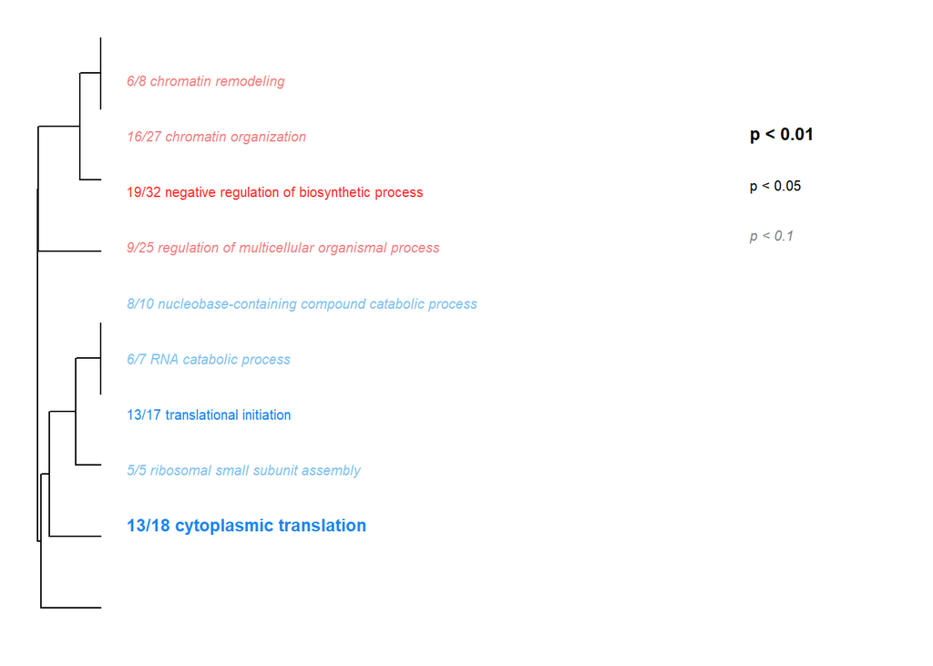

```
## GO terms dispayed:  9
## "Good genes" accounted for:  63 out of 257 ( 25% )
```

```r
# do not continue if the printout shows that no GO terms pass 10% FDR.


# Plotting results
results=gomwuPlot(input,goAnnotations,goDivision,
                  # absValue=-log(0.05,10),  # genes with the measure value exceeding this will be counted as "good genes". Specify absValue=0.001 if you are doing Fisher's exact test for standard GO enrichment or analyzing a WGCNA module (all non-zero genes = "good genes").
                  absValue=1,
                  level1=0.1, # FDR threshold for plotting. Specify level1=1 to plot all GO categories containing genes exceeding the absValue.
                  level2=0.05, # FDR cutoff to print in regular (not italic) font.
                  level3=0.01, # FDR cutoff to print in large bold font.
                  txtsize=1.2,    # decrease to fit more on one page, or increase (after rescaling the plot so the tree fits the text) for better "word cloud" effect
                  treeHeight=0.5, # height of the hierarchical clustering tree
                  # colors=c("dodgerblue2","firebrick1","skyblue2","lightcoral") # these are default colors, un-remar and change if needed
)
```

```r
# manually rescale the plot so the tree matches the text
# if there are too many categories displayed, try make it more stringent with level1=0.05,level2=0.01,level3=0.001.

# text representation of results, with actual adjusted p-values
results
```

```
##                                                              pval
## 13/18 cytoplasmic translation                         0.006967591
## 5/5 ribosomal small subunit assembly                  0.092201545
## 13/17 translational initiation                        0.037631393
## 6/7 RNA catabolic process                             0.092201545
## 8/10 nucleobase-containing compound catabolic process 0.059325052
## 9/25 regulation of multicellular organismal process   0.092201545
## 19/32 negative regulation of biosynthetic process     0.037631393
## 16/27 chromatin organization                          0.071292038
## 6/8 chromatin remodeling                              0.092201545
##                                                       direction
## 13/18 cytoplasmic translation                                 0
## 5/5 ribosomal small subunit assembly                          0
## 13/17 translational initiation                                0
## 6/7 RNA catabolic process                                     0
## 8/10 nucleobase-containing compound catabolic process         0
## 9/25 regulation of multicellular organismal process           1
## 19/32 negative regulation of biosynthetic process             1
## 16/27 chromatin organization                                  1
## 6/8 chromatin remodeling                                      1
##                                                             color
## 13/18 cytoplasmic translation                         dodgerblue2
## 5/5 ribosomal small subunit assembly                     skyblue2
## 13/17 translational initiation                        dodgerblue2
## 6/7 RNA catabolic process                                skyblue2
## 8/10 nucleobase-containing compound catabolic process    skyblue2
## 9/25 regulation of multicellular organismal process    lightcoral
## 19/32 negative regulation of biosynthetic process      firebrick1
## 16/27 chromatin organization                           lightcoral
## 6/8 chromatin remodeling                               lightcoral
```

```r
#GO enrichment analysis
#######CC
goDivision="CC" # either MF, or BP, or CC

# Calculating stats. It might take ~3 min for MF and BP. Do not rerun it if you just want to replot the data with different cutoffs, go straight to gomwuPlot. If you change any of the numeric values below, delete the files that were generated in previos runs first.
gomwuStats(input, goDatabase, goAnnotations, goDivision,
           perlPath="perl", # replace with full path to perl executable if it is not in your system's PATH already
           largest=0.1,  # a GO category will not be considered if it contains more than this fraction of the total number of genes
           smallest=5,   # a GO category should contain at least this many genes to be considered
           clusterCutHeight=0.25, # threshold for merging similar (gene-sharing) terms. See README for details.
           #    Alternative="g" # by default the MWU test is two-tailed; specify "g" or "l" of you want to test for "greater" or "less" instead.
           #    Module=TRUE,Alternative="g" # un-remark this if you are analyzing a SIGNED WGCNA module (values: 0 for not in module genes, kME for in-module genes). In the call to gomwuPlot below, specify absValue=0.001 (count number of "good genes" that fall into the module)
           #    Module=TRUE # un-remark this if you are analyzing an UNSIGNED WGCNA module
)
```

```
## Continuous measure of interest: will perform MWU test
## 14  GO terms at 10% FDR
```

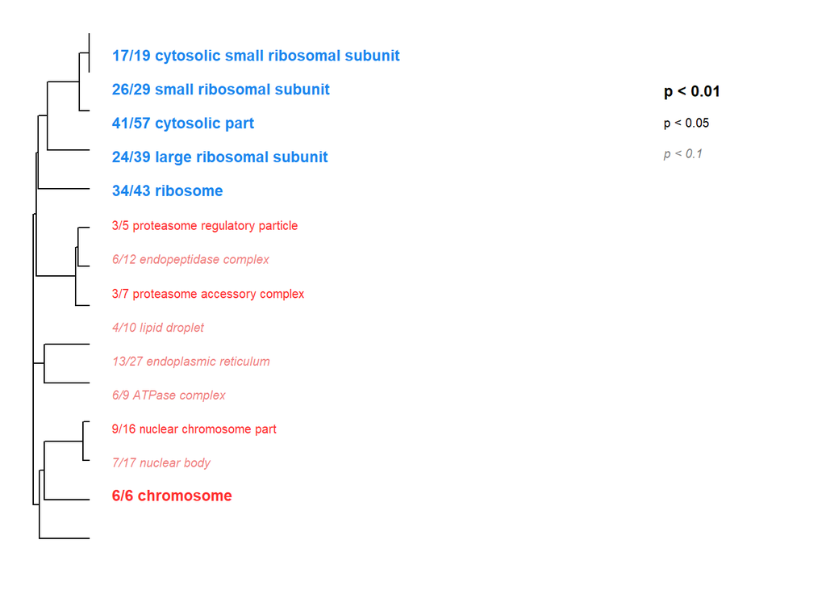

```
## GO terms dispayed:  14
## "Good genes" accounted for:  125 out of 272 ( 46% )
```

```r
# do not continue if the printout shows that no GO terms pass 10% FDR.


# Plotting results
results=gomwuPlot(input,goAnnotations,goDivision,
                  # absValue=-log(0.05,10),  # genes with the measure value exceeding this will be counted as "good genes". Specify absValue=0.001 if you are doing Fisher's exact test for standard GO enrichment or analyzing a WGCNA module (all non-zero genes = "good genes").
                  absValue=1,
                  level1=0.1, # FDR threshold for plotting. Specify level1=1 to plot all GO categories containing genes exceeding the absValue.
                  level2=0.05, # FDR cutoff to print in regular (not italic) font.
                  level3=0.01, # FDR cutoff to print in large bold font.
                  txtsize=1.2,    # decrease to fit more on one page, or increase (after rescaling the plot so the tree fits the text) for better "word cloud" effect
                  treeHeight=0.5, # height of the hierarchical clustering tree
                  # colors=c("dodgerblue2","firebrick1","skyblue2","lightcoral") # these are default colors, un-remar and change if needed
)
```

```r
# manually rescale the plot so the tree matches the text
# if there are too many categories displayed, try make it more stringent with level1=0.05,level2=0.01,level3=0.001.

# text representation of results, with actual adjusted p-values
results
```

```
##                                                 pval direction       color
## 6/6 chromosome                          5.343188e-03         1  firebrick1
## 7/17 nuclear body                       9.265581e-02         1  lightcoral
## 9/16 nuclear chromosome part            1.890395e-02         1  firebrick1
## 6/9 ATPase complex                      7.111051e-02         1  lightcoral
## 13/27 endoplasmic reticulum             9.903385e-02         1  lightcoral
## 4/10 lipid droplet                      9.903385e-02         1  lightcoral
## 3/7 proteasome accessory complex        3.889244e-02         1  firebrick1
## 6/12 endopeptidase complex              9.903385e-02         1  lightcoral
## 3/5 proteasome regulatory particle      3.889244e-02         1  firebrick1
## 34/43 ribosome                          8.339747e-07         0 dodgerblue2
## 24/39 large ribosomal subunit           2.351880e-03         0 dodgerblue2
## 41/57 cytosolic part                    2.141175e-05         0 dodgerblue2
## 26/29 small ribosomal subunit           8.339747e-07         0 dodgerblue2
## 17/19 cytosolic small ribosomal subunit 1.270207e-04         0 dodgerblue2
```

The GO enrichment analyses overall show that positively enriched genes are primarily involved in nuclear and chromosomal function and negatively enriched genes are involved with ribosomal and protein functions.

```r
#Get pvals and make an rlogadata and pval table
#get pvals
val7548=cbind(respH75.48$pvalue, respH75.48$padj)
head(val7548)
```

```
##           [,1]      [,2]
## [1,] 0.6720040        NA
## [2,] 0.8033134 0.9554177
## [3,] 0.7255406 0.9273710
## [4,] 0.7165829        NA
## [5,] 0.8156569        NA
## [6,] 0.5563739 0.8763567
```

```r
colnames(val7548)=c("pval.7548", "padj.7548")
length(val7548[,1])
```

```
## [1] 20788
```

```r
#20788
table(complete.cases(val7548))
```

```
##
## FALSE  TRUE
## 18597  2191
```

```r
# FALSE  TRUE
# 18597  2191

#make rlogdata and pvals table
rlog48=rlogTransformation(dds48, blind=TRUE)
rld48=assay(rlog48)
head(rld48)
```

```
##               b37_48_7.5_1 b37_48_7.5_2 b37_48_7.5_3 b37_48_7.5_4
## isogroup00002    1.2829786    1.7322613    1.7895830    1.4714945
## isogroup00004    4.9421222    4.8284890    5.8230762    5.4503359
## isogroup00006    4.7235834    4.6611068    4.6496610    4.9374610
## isogroup00007    0.1711824    0.3351114    0.3741152    0.2926734
## isogroup00008    0.5364229    0.7096945    0.4430907    0.5537755
## isogroup00009    4.8863297    4.7839028    4.6967850    4.6083848
##               b37_48_8_1 b37_48_8_2 b37_48_8_3 b37_48_8_4
## isogroup00002  1.7818607 1.37002604  1.7946969  1.7027323
## isogroup00004  5.0096884 5.26543943  5.5544345  4.9728007
## isogroup00006  4.9571699 4.94664809  4.5518341  4.7207240
## isogroup00007  0.6503119 0.01332048  0.1231906  0.0527405
## isogroup00008  0.5137736 0.54041127  0.4033909  0.6458861
## isogroup00009  4.4292925 4.40652900  5.0464763  4.6356928
```

```r
colnames(rld48)=paste(colData48$treat)
head(rld48)
```

```
##                   pH7.5     pH7.5     pH7.5     pH7.5       pH8        pH8
## isogroup00002 1.2829786 1.7322613 1.7895830 1.4714945 1.7818607 1.37002604
## isogroup00004 4.9421222 4.8284890 5.8230762 5.4503359 5.0096884 5.26543943
## isogroup00006 4.7235834 4.6611068 4.6496610 4.9374610 4.9571699 4.94664809
## isogroup00007 0.1711824 0.3351114 0.3741152 0.2926734 0.6503119 0.01332048
## isogroup00008 0.5364229 0.7096945 0.4430907 0.5537755 0.5137736 0.54041127
## isogroup00009 4.8863297 4.7839028 4.6967850 4.6083848 4.4292925 4.40652900
##                     pH8       pH8
## isogroup00002 1.7946969 1.7027323
## isogroup00004 5.5544345 4.9728007
## isogroup00006 4.5518341 4.7207240
## isogroup00007 0.1231906 0.0527405
## isogroup00008 0.4033909 0.6458861
## isogroup00009 5.0464763 4.6356928
```

```r
length(rld48[,1])
```

```
## [1] 20788
```

```r
#20788

rldpvals48=cbind(rld48,val7548)
head(rldpvals48)
```

```
##                   pH7.5     pH7.5     pH7.5     pH7.5       pH8        pH8
## isogroup00002 1.2829786 1.7322613 1.7895830 1.4714945 1.7818607 1.37002604
## isogroup00004 4.9421222 4.8284890 5.8230762 5.4503359 5.0096884 5.26543943
## isogroup00006 4.7235834 4.6611068 4.6496610 4.9374610 4.9571699 4.94664809
## isogroup00007 0.1711824 0.3351114 0.3741152 0.2926734 0.6503119 0.01332048
## isogroup00008 0.5364229 0.7096945 0.4430907 0.5537755 0.5137736 0.54041127
## isogroup00009 4.8863297 4.7839028 4.6967850 4.6083848 4.4292925 4.40652900
##                     pH8       pH8 pval.7548 padj.7548
## isogroup00002 1.7946969 1.7027323 0.6720040        NA
## isogroup00004 5.5544345 4.9728007 0.8033134 0.9554177
## isogroup00006 4.5518341 4.7207240 0.7255406 0.9273710
## isogroup00007 0.1231906 0.0527405 0.7165829        NA
## isogroup00008 0.4033909 0.6458861 0.8156569        NA
## isogroup00009 5.0464763 4.6356928 0.5563739 0.8763567
```

```r
dim(rldpvals48)
```

```
## [1] 20788    10
```

```r
# [1] 20788    10
table(complete.cases(rldpvals48))
```

```
##
## FALSE  TRUE
## 18597  2191
```

```r
# FALSE  TRUE
# 18597  2191

write.csv(rldpvals48, "Crep2017_b37Final_RLDandPVALS_48.csv", quote=F)
```

```
## Found more than one class "unit" in cache; using the first, from namespace 'ggbio'
```

```
## Also defined by 'hexbin'
```

```
## Found more than one class "unit" in cache; using the first, from namespace 'ggbio'
```

```
## Also defined by 'hexbin'
```

```
## Found more than one class "unit" in cache; using the first, from namespace 'ggbio'
```

```
## Also defined by 'hexbin'
```

```
## Found more than one class "unit" in cache; using the first, from namespace 'ggbio'
```

```
## Also defined by 'hexbin'
```

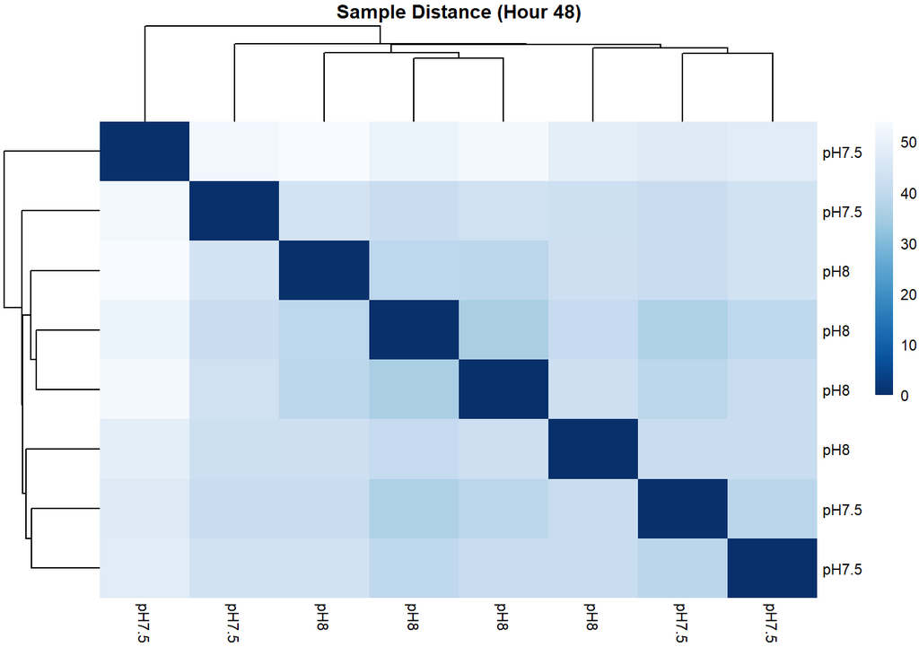

```r
#Sample distance heatmap
sampleDists48 <- dist(t(rld48))
sampleDistsMatrix48 <- as.matrix(sampleDists48)
treat48=c( "pH7.5", "pH7.5", "pH7.5", "pH7.5", "pH8", "pH8",  "pH8", "pH8")
colnames(sampleDistsMatrix48)=paste(treat48)
rownames(sampleDistsMatrix48)=paste(treat48)
colors <- colorRampPalette( rev(brewer.pal(9, "Blues")) )(255)
pheatmap(sampleDistsMatrix48,color=colors,cex=0.9,border_color=NA,clustering_distance_rows=sampleDists48,clustering_distance_cols=sampleDists48, main="Sample Distance (Hour 48)")
```

```r
#PCA and adonis
rld_t48=t(rld48)
# which(apply(rld_t48, 2, var)==0) #identify which columns have zero variance, PCA will not work on these
rld_t48 = rld_t48[ , apply(rld_t48, 2, var) != 0] #removes columns with zero variance
pca <- prcomp(rld_t48,center = TRUE, scale. = TRUE) #Scale = TRUE is advisable
# head(pca)
li <- pca$sdev^2 / sum(pca$sdev^2)
pc1v <- round(li[1] * 100, 1)
pc2v <- round(li[2] * 100, 1)
pca_s <- as.data.frame(pca$x)
head(pca_s)
```

```
##                 PC1         PC2        PC3        PC4        PC5
## pH7.5   -148.890815  23.6071597 -19.931111   3.831616  -5.365566
## pH7.5.1    5.138746   0.7903978  94.928503  72.724241 -23.667023
## pH7.5.2   24.139657 -91.7678001   8.989521 -13.343340  -2.816087
## pH7.5.3   -2.553296 -25.4632709  20.706818 -13.006578  28.608279
## pH8       45.145095  11.1751102 -87.336407  57.718653 -60.001245
## pH8.1     33.518065  68.4166065  28.245805 -85.867116 -55.672985
##                 PC6        PC7           PC8
## pH7.5   -19.7418096  -9.650413  5.756281e-13
## pH7.5.1   0.7728124  39.122915  1.605335e-13
## pH7.5.2 -72.8552351 -49.432219 -2.151790e-12
## pH7.5.3  97.8140366 -58.347389  6.118075e-13
## pH8      16.3784209  -8.162193  8.769476e-13
## pH8.1    -8.9626312  -2.192810  1.032118e-12
```

```r
pca_s <- pca_s[,c(1,2)]
pca_s$Samples = row.names(pca_s)
pca_s$treat=colData48$treat
head(pca_s)
```

```
##                 PC1         PC2 Samples treat
## pH7.5   -148.890815  23.6071597   pH7.5 pH7.5
## pH7.5.1    5.138746   0.7903978 pH7.5.1 pH7.5
## pH7.5.2   24.139657 -91.7678001 pH7.5.2 pH7.5
## pH7.5.3   -2.553296 -25.4632709 pH7.5.3 pH7.5
## pH8       45.145095  11.1751102     pH8   pH8
## pH8.1     33.518065  68.4166065   pH8.1   pH8
```

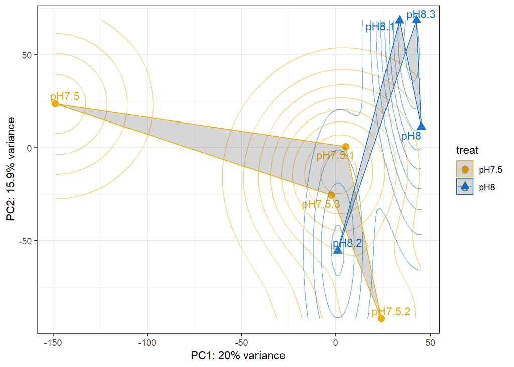

```r
cbPalette <- c("darkgoldenrod2", "dodgerblue3")
ggplot(pca_s, aes(PC1, PC2, color = treat, pch = treat)) +
  geom_point(size=3) +
  geom_text_repel(aes(label=Samples)) +
  scale_colour_manual(values=cbPalette)+
  theme_bw() +
  geom_density2d(alpha=.5)+
  geom_polygon(alpha=.2)+
  xlab(paste0("PC1: ",pc1v,"% variance")) +
  ylab(paste0("PC2: ",pc2v,"% variance"))
```

```r
adonis(pca$x ~ treat, data = pca_s, method='eu', na.rm = TRUE)
```

```
##
## Call:
## adonis(formula = pca$x ~ treat, data = pca_s, method = "eu",      na.rm = TRUE)
##
## Permutation: free
## Number of permutations: 999
##
## Terms added sequentially (first to last)
##
##           Df SumsOfSqs MeanSqs F.Model      R2 Pr(>F)
## treat      1     21601   21601  1.1045 0.15546  0.099 .
## Residuals  6    117349   19558         0.84454
## Total      7    138950                 1.00000
## ---
## Signif. codes:  0 '***' 0.001 '**' 0.01 '*' 0.05 '.' 0.1 ' ' 1
```

```r
#           # Df SumsOfSqs MeanSqs F.Model      R2 Pr(>F)
# # treat      1     21601   21601  1.1045 0.15546  0.086 .
# # Residuals  6    117349   19558         0.84454
# # Total      7    138950                 1.00000
```

```r
#Heatmap for genes
source("uniHeatmap.R")
ccol=colorRampPalette(rev(c("red","chocolate1","#FEE090","grey10", "cyan3","cyan")))(100)
col0=colorRampPalette(rev(c("chocolate1","#FEE090","grey10", "cyan3","cyan")))(100)

#Hour 48 pH7.5 v pH8
rldpvals48 <- read.csv(file="Crep2017_b37Final_RLDandPVALS_48.csv", row.names=1)
head(rldpvals48)
```

```
##                   pH7.5   pH7.5.1   pH7.5.2   pH7.5.3       pH8      pH8.1
## isogroup00002 1.2829786 1.7322613 1.7895830 1.4714945 1.7818607 1.37002604
## isogroup00004 4.9421222 4.8284890 5.8230762 5.4503359 5.0096884 5.26543943
## isogroup00006 4.7235834 4.6611068 4.6496610 4.9374610 4.9571699 4.94664809
## isogroup00007 0.1711824 0.3351114 0.3741152 0.2926734 0.6503119 0.01332048
## isogroup00008 0.5364229 0.7096945 0.4430907 0.5537755 0.5137736 0.54041127
## isogroup00009 4.8863297 4.7839028 4.6967850 4.6083848 4.4292925 4.40652900
##                   pH8.2     pH8.3 pval.7548 padj.7548
## isogroup00002 1.7946969 1.7027323 0.6720040        NA
## isogroup00004 5.5544345 4.9728007 0.8033134 0.9554177
## isogroup00006 4.5518341 4.7207240 0.7255406 0.9273710
## isogroup00007 0.1231906 0.0527405 0.7165829        NA
## isogroup00008 0.4033909 0.6458861 0.8156569        NA
## isogroup00009 5.0464763 4.6356928 0.5563739 0.8763567
```

```r
rld_site48= rldpvals48[,1:8]
head(rld_site48)
```

```
##                   pH7.5   pH7.5.1   pH7.5.2   pH7.5.3       pH8      pH8.1
## isogroup00002 1.2829786 1.7322613 1.7895830 1.4714945 1.7818607 1.37002604
## isogroup00004 4.9421222 4.8284890 5.8230762 5.4503359 5.0096884 5.26543943
## isogroup00006 4.7235834 4.6611068 4.6496610 4.9374610 4.9571699 4.94664809
## isogroup00007 0.1711824 0.3351114 0.3741152 0.2926734 0.6503119 0.01332048
## isogroup00008 0.5364229 0.7096945 0.4430907 0.5537755 0.5137736 0.54041127
## isogroup00009 4.8863297 4.7839028 4.6967850 4.6083848 4.4292925 4.40652900
##                   pH8.2     pH8.3
## isogroup00002 1.7946969 1.7027323
## isogroup00004 5.5544345 4.9728007
## isogroup00006 4.5518341 4.7207240
## isogroup00007 0.1231906 0.0527405
## isogroup00008 0.4033909 0.6458861
## isogroup00009 5.0464763 4.6356928
```

```r
gg=read.table("Crep454_iso2gene.tab",sep="\t")
head(gg)
```

```
##              V1
## 1 isogroup09134
## 2 isogroup16273
## 3 isogroup38437
## 4 isogroup14351
## 5 isogroup28998
## 6 isogroup15722
##                                                                                                                     V2
## 1                                                   Protein ABHD18 OS=Mus musculus GN=Abhd18 PE=2 SV=1 E(blastx)=6e-52
## 2                                    Poly [ADP-ribose] polymerase 1 OS=Homo sapiens GN=PARP1 PE=1 SV=4 E(blastx)=2e-49
## 3                             ER lumen protein-retaining receptor 2 OS=Danio rerio GN=kdelr2 PE=2 SV=1 E(blastx)=3e-94
## 4 Mitochondrial import inner membrane translocase subunit Tim8 A OS=Xenopus laevis GN=timm8a PE=3 SV=1 E(blastx)=1e-28
## 5                                AP-2 complex subunit mu OS=Caenorhabditis elegans GN=dpy-23 PE=2 SV=2 E(blastx)=4e-17
## 6  Somatomedin-B and thrombospondin type-1 domain-containing protein OS=Bos taurus GN=SBSPON PE=2 SV=2 E(blastx)=7e-07
```

```r
nrow(rldpvals48[rldpvals48$padj.7548<0.01& !is.na(rldpvals48$padj.7548),])
```

```
## [1] 9
```

```r
#9

topnum= 500 # number of DEGS between treatments
head(rldpvals48)
```

```
##                   pH7.5   pH7.5.1   pH7.5.2   pH7.5.3       pH8      pH8.1
## isogroup00002 1.2829786 1.7322613 1.7895830 1.4714945 1.7818607 1.37002604
## isogroup00004 4.9421222 4.8284890 5.8230762 5.4503359 5.0096884 5.26543943
## isogroup00006 4.7235834 4.6611068 4.6496610 4.9374610 4.9571699 4.94664809
## isogroup00007 0.1711824 0.3351114 0.3741152 0.2926734 0.6503119 0.01332048
## isogroup00008 0.5364229 0.7096945 0.4430907 0.5537755 0.5137736 0.54041127
## isogroup00009 4.8863297 4.7839028 4.6967850 4.6083848 4.4292925 4.40652900
##                   pH8.2     pH8.3 pval.7548 padj.7548
## isogroup00002 1.7946969 1.7027323 0.6720040        NA
## isogroup00004 5.5544345 4.9728007 0.8033134 0.9554177
## isogroup00006 4.5518341 4.7207240 0.7255406 0.9273710
## isogroup00007 0.1231906 0.0527405 0.7165829        NA
## isogroup00008 0.4033909 0.6458861 0.8156569        NA
## isogroup00009 5.0464763 4.6356928 0.5563739 0.8763567
```

```r
top1000=head(rldpvals48[order(rldpvals48$padj.7548), ],topnum)
head(top1000)
```

```
##                  pH7.5  pH7.5.1  pH7.5.2  pH7.5.3      pH8    pH8.1
## isogroup07687 3.065685 2.965034 3.881881 3.929169 6.467410 6.354861
## isogroup12893 3.206948 2.828541 3.844212 3.348283 6.142243 5.408314
## isogroup03759 4.187408 3.955814 4.376687 4.118190 5.467062 5.672423
## isogroup13999 5.363443 5.029011 4.616946 5.510251 6.375859 6.310155
## isogroup02282 6.276138 6.274582 5.675655 5.517438 4.881386 4.489534
## isogroup02218 5.798413 5.712521 5.805315 5.321887 4.215955 4.577186
##                  pH8.2    pH8.3    pval.7548    padj.7548
## isogroup07687 5.414187 6.756544 3.409918e-26 7.471130e-23
## isogroup12893 5.537729 5.911606 1.413899e-22 1.548926e-19
## isogroup03759 4.961784 5.794304 3.464431e-10 2.530189e-07
## isogroup13999 6.326035 6.482587 2.711154e-09 1.485035e-06
## isogroup02282 5.098192 4.425590 1.077234e-08 4.720437e-06
## isogroup02218 4.299036 4.659632 1.665122e-08 6.080470e-06
```

```r
length(top1000[,1])
```

```
## [1] 500
```

```r
summary(top1000)
```

```
##      pH7.5           pH7.5.1          pH7.5.2          pH7.5.3
##  Min.   : 3.066   Min.   : 2.829   Min.   : 3.714   Min.   : 3.348
##  1st Qu.: 5.343   1st Qu.: 5.118   1st Qu.: 5.110   1st Qu.: 5.165
##  Median : 6.224   Median : 6.000   Median : 6.077   Median : 6.116
##  Mean   : 6.443   Mean   : 6.362   Mean   : 6.430   Mean   : 6.459
##  3rd Qu.: 7.288   3rd Qu.: 7.193   3rd Qu.: 7.322   3rd Qu.: 7.326
##  Max.   :10.784   Max.   :10.897   Max.   :11.531   Max.   :11.299
##       pH8             pH8.1            pH8.2            pH8.3
##  Min.   : 3.987   Min.   : 3.828   Min.   : 3.769   Min.   : 3.763
##  1st Qu.: 5.273   1st Qu.: 5.224   1st Qu.: 5.170   1st Qu.: 5.213
##  Median : 6.223   Median : 6.176   Median : 6.209   Median : 6.220
##  Mean   : 6.659   Mean   : 6.507   Mean   : 6.541   Mean   : 6.582
##  3rd Qu.: 7.669   3rd Qu.: 7.457   3rd Qu.: 7.480   3rd Qu.: 7.519
##  Max.   :11.656   Max.   :11.316   Max.   :11.596   Max.   :11.557
##    pval.7548         padj.7548
##  Min.   :0.00000   Min.   :0.0000
##  1st Qu.:0.01539   1st Qu.:0.2673
##  Median :0.04287   Median :0.3748
##  Mean   :0.04825   Mean   :0.3527
##  3rd Qu.:0.07845   3rd Qu.:0.4571
##  Max.   :0.11919   Max.   :0.5223
```

```r
head(top1000)
```

```
##                  pH7.5  pH7.5.1  pH7.5.2  pH7.5.3      pH8    pH8.1
## isogroup07687 3.065685 2.965034 3.881881 3.929169 6.467410 6.354861
## isogroup12893 3.206948 2.828541 3.844212 3.348283 6.142243 5.408314
## isogroup03759 4.187408 3.955814 4.376687 4.118190 5.467062 5.672423
## isogroup13999 5.363443 5.029011 4.616946 5.510251 6.375859 6.310155
## isogroup02282 6.276138 6.274582 5.675655 5.517438 4.881386 4.489534
## isogroup02218 5.798413 5.712521 5.805315 5.321887 4.215955 4.577186
##                  pH8.2    pH8.3    pval.7548    padj.7548
## isogroup07687 5.414187 6.756544 3.409918e-26 7.471130e-23
## isogroup12893 5.537729 5.911606 1.413899e-22 1.548926e-19
## isogroup03759 4.961784 5.794304 3.464431e-10 2.530189e-07
## isogroup13999 6.326035 6.482587 2.711154e-09 1.485035e-06
## isogroup02282 5.098192 4.425590 1.077234e-08 4.720437e-06
## isogroup02218 4.299036 4.659632 1.665122e-08 6.080470e-06
```

```r
p.val=0.1 # FDR cutoff
conds=top1000[top1000$padj.7548<=p.val & !is.na(top1000$padj.7548),]
length(conds[,1])
```

```
## [1] 25
```

```r
#25

exp=conds[,c(1:8)] # change numbers to be your vsd data columns
means=apply(exp,1,mean) # means of rows
explc=exp-means # subtracting them
head(explc)
```

```
##                    pH7.5    pH7.5.1    pH7.5.2    pH7.5.3        pH8
## isogroup07687 -1.7886617 -1.8893127 -0.9724649 -0.9251775  1.6130639
## isogroup12893 -1.3215369 -1.6999434 -0.6842726 -1.1802010  1.6137582
## isogroup03759 -0.6293014 -0.8608953 -0.4400217 -0.6985193  0.6503533
## isogroup13999 -0.3883429 -0.7227751 -1.1348393 -0.2415352  0.6240728
## isogroup02282  0.9463234  0.9447678  0.3458405  0.1876233 -0.4484285
## isogroup02218  0.7496702  0.6637775  0.7565717  0.2731439 -0.8327882
##                    pH8.1      pH8.2      pH8.3
## isogroup07687  1.5005147  0.5598408  1.9021974
## isogroup12893  0.8798298  1.0092442  1.3831217
## isogroup03759  0.8557137  0.1450755  0.9775953
## isogroup13999  0.5583691  0.5742490  0.7308017
## isogroup02282 -0.8402798 -0.2316222 -0.9042246
## isogroup02218 -0.4715571 -0.7497072 -0.3891108
```

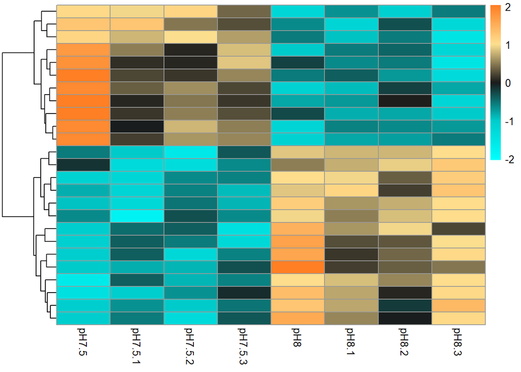

```r
pheatmap(explc,cluster_cols=F,scale="row",color=col0, show_rownames = F)
```

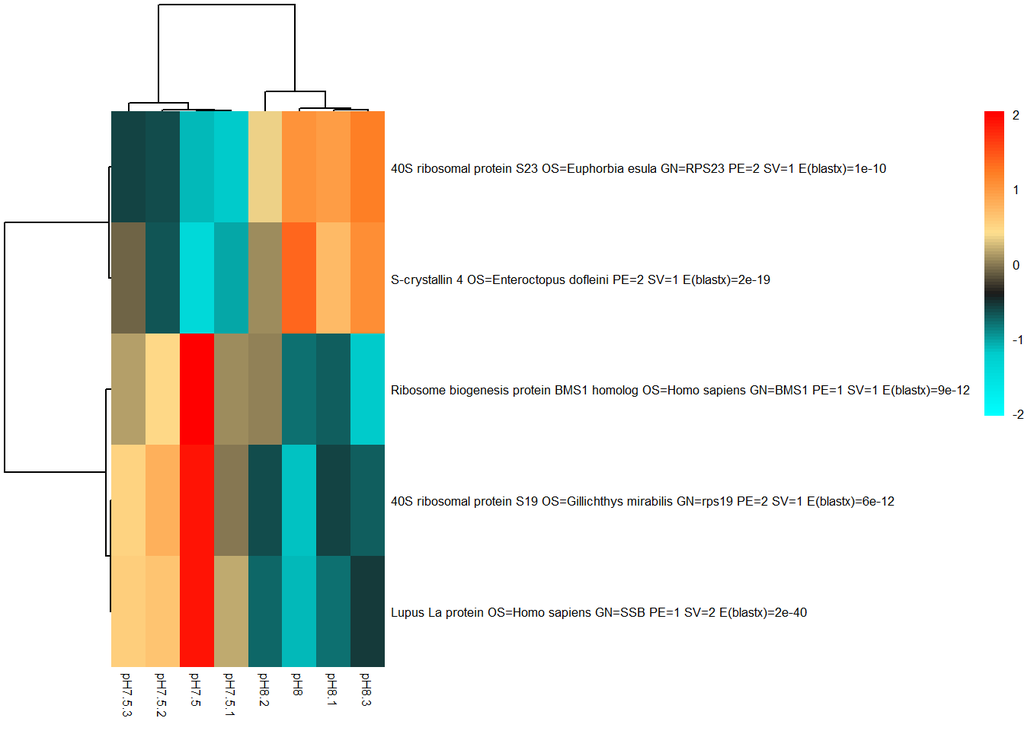

```r
nums=uniHeatmap(vsd=explc,gene.names=gg,metric=top1000$padj.7548, cutoff=0.1,pdf=F,heat.color=ccol,cex=0.8)
```

```r
nums # totalCutoffPassing(25), named(5), patternMatching(0)
```

```
## [1] 25  5  0
```

Among the 25 DEGs, we clearly see separation between treatments. Among those, 5 are named and appear to be related to ribosomes and proteins, indicative of protein synthesis being affected by acidification.

```r
#Heatmap for genes in common
source("uniHeatmap.R")

#Hour 48
rldpvals48 <- read.csv(file="Crep2017_b37Final_RLDandPVALS_48.csv", row.names=1)
head(rldpvals48)
```

```
##                   pH7.5   pH7.5.1   pH7.5.2   pH7.5.3       pH8      pH8.1
## isogroup00002 1.2829786 1.7322613 1.7895830 1.4714945 1.7818607 1.37002604
## isogroup00004 4.9421222 4.8284890 5.8230762 5.4503359 5.0096884 5.26543943
## isogroup00006 4.7235834 4.6611068 4.6496610 4.9374610 4.9571699 4.94664809
## isogroup00007 0.1711824 0.3351114 0.3741152 0.2926734 0.6503119 0.01332048
## isogroup00008 0.5364229 0.7096945 0.4430907 0.5537755 0.5137736 0.54041127
## isogroup00009 4.8863297 4.7839028 4.6967850 4.6083848 4.4292925 4.40652900
##                   pH8.2     pH8.3 pval.7548 padj.7548
## isogroup00002 1.7946969 1.7027323 0.6720040        NA
## isogroup00004 5.5544345 4.9728007 0.8033134 0.9554177
## isogroup00006 4.5518341 4.7207240 0.7255406 0.9273710
## isogroup00007 0.1231906 0.0527405 0.7165829        NA
## isogroup00008 0.4033909 0.6458861 0.8156569        NA
## isogroup00009 5.0464763 4.6356928 0.5563739 0.8763567
```

```r
p.val=0.1 # FDR cutoff
conds=rldpvals48[rldpvals48$padj.7548<=p.val & !is.na(rldpvals48$padj.7548) & rldpvals48$padj.7548<=p.val & !is.na(rldpvals48$padj.7548),]
rld_data= conds[,c(1:8)]
head(rld_data)
```

```
##                  pH7.5  pH7.5.1  pH7.5.2  pH7.5.3      pH8    pH8.1
## isogroup00017 5.850883 4.983422 4.941559 5.145370 4.594126 4.692424
## isogroup01959 4.534940 4.055188 4.659604 4.534030 5.188669 4.999794
## isogroup02218 5.798413 5.712521 5.805315 5.321887 4.215955 4.577186
## isogroup02282 6.276138 6.274582 5.675655 5.517438 4.881386 4.489534
## isogroup02982 5.994442 5.101658 5.284920 5.165399 4.907748 4.642148
## isogroup03680 6.401146 5.651734 5.777574 5.597113 4.934926 5.041220
##                  pH8.2    pH8.3
## isogroup00017 4.525390 4.243518
## isogroup01959 5.131828 5.226788
## isogroup02218 4.299036 4.659632
## isogroup02282 5.098192 4.425590
## isogroup02982 4.658170 4.561854
## isogroup03680 5.376480 5.095373
```

```r
nrow(rld_data)
```

```
## [1] 25
```

```r
gg=read.table("Crep454_iso2gene.tab",sep="\t")
```

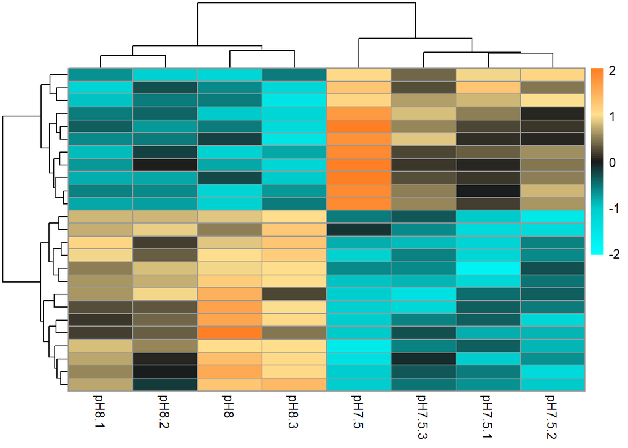

```r
means=apply(rld_data,1,mean) # means of rows
explc=rld_data-means # subtracting them

ccol=colorRampPalette(rev(c("red","chocolate1","#FEE090","grey10", "cyan3","cyan")))(100)
col0=colorRampPalette(rev(c("chocolate1","#FEE090","grey10", "cyan3","cyan")))(100)

pheatmap(explc,cluster_cols=T,scale="row",color=col0, show_rownames = F)
```

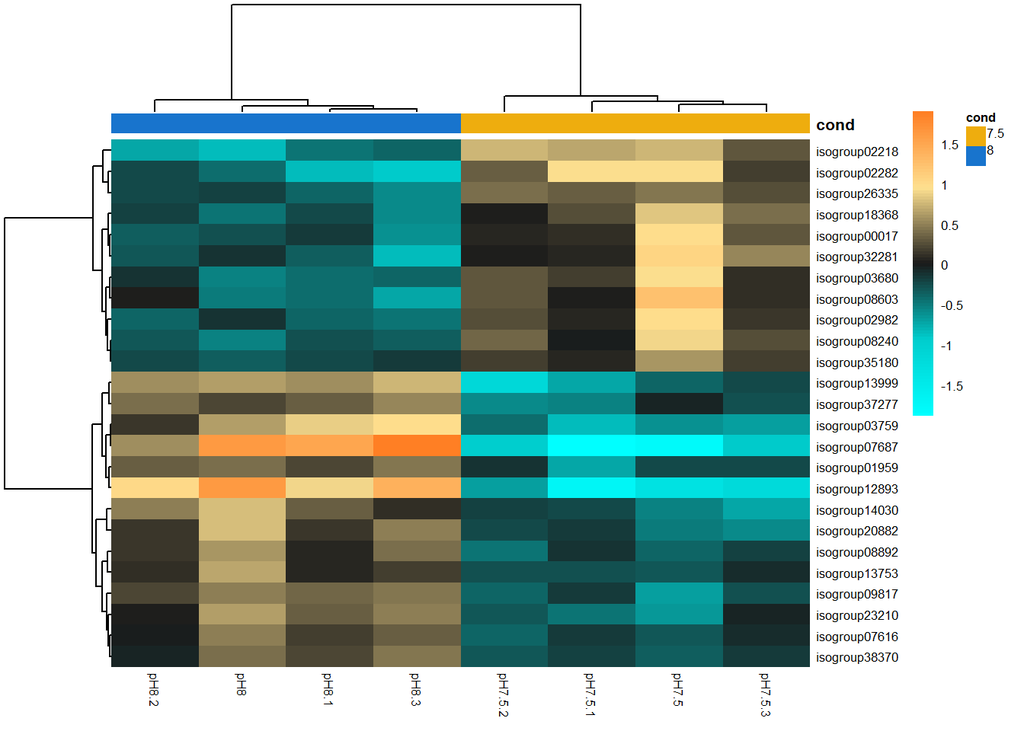

```r
# Make annotation table for pheatmap
ann = data.frame(cond = c('7.5', '7.5', '7.5', '7.5', '8', '8', '8', '8'))
rownames(ann) <- names(explc)

# Set colors
Var1        <- c("darkgoldenrod2", "dodgerblue3")
names(Var1) <- c("7.5", "8")
anno_colors <- list(cond = Var1)

pheatmap(as.matrix(explc),annotation_col=ann,annotation_colors=anno_colors,cex=0.8,color=col0,border_color=NA,clustering_distance_rows="correlation",clustering_distance_cols="correlation", show_rownames=T)
```

```r
head(conds)
```

```
##                  pH7.5  pH7.5.1  pH7.5.2  pH7.5.3      pH8    pH8.1
## isogroup00017 5.850883 4.983422 4.941559 5.145370 4.594126 4.692424
## isogroup01959 4.534940 4.055188 4.659604 4.534030 5.188669 4.999794
## isogroup02218 5.798413 5.712521 5.805315 5.321887 4.215955 4.577186
## isogroup02282 6.276138 6.274582 5.675655 5.517438 4.881386 4.489534
## isogroup02982 5.994442 5.101658 5.284920 5.165399 4.907748 4.642148
## isogroup03680 6.401146 5.651734 5.777574 5.597113 4.934926 5.041220
##                  pH8.2    pH8.3    pval.7548    padj.7548
## isogroup00017 4.525390 4.243518 1.004166e-03 9.167201e-02
## isogroup01959 5.131828 5.226788 7.720531e-04 8.457842e-02
## isogroup02218 4.299036 4.659632 1.665122e-08 6.080470e-06
## isogroup02282 5.098192 4.425590 1.077234e-08 4.720437e-06
## isogroup02982 4.658170 4.561854 9.923980e-04 9.167201e-02
## isogroup03680 5.376480 5.095373 2.222296e-04 3.662413e-02
```

```r
#nums=uniHeatmap(vsd=explc,gene.names=gg, metric=conds$padj.7548, sort=F, cutoff=0.2,pdf=F,heat.color=ccol, annotation_col=ann,annotation_colors=anno_colors,cex=1.2)
```

Conclusion: We assessed changes in the gene expression of the intertidal snail Crepidula fornicata after exposure to ocean acidification stress for 48 hours. We found 25 differentially expressed genes (DEGs) between the pH 7.5 and pH 8.0 treatments, with 11 genes upregulated 14 downregulated by the pH 7.5 treatment relative to the control. A non-significant PCA showed that treatments clustered but also overlapped. Go enrichment analysis identified positively enriched genes as ones primarily involved in nuclear and chromosomal function and negatively enriched genes as ones involved with ribosomal and protein functions. These analyses suggests that changes in gene expression can occur over a short period of time, and thus, future studies should aim at analyzing gene expression across various time intervals to get a more holistic representation of how an organism is affected by a stressor.